# soution

```python
df.user_id.nunique()
```

```
102623
```

one row per customer!

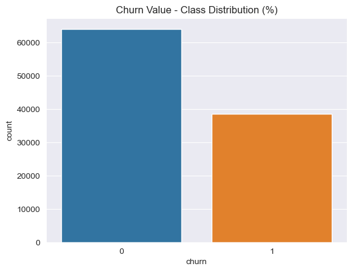

```python
sns.countplot(x=df["churn"])
plt.title("Churn Value - Class Distribution (%)")
plt.show()
```

```python
df.churn.value_counts()
```

```
0    64065
1    38558
Name: churn, dtype: int64
```

```python
df.churn.mean()
```

```
0.3757247400680159
```

37% churn!

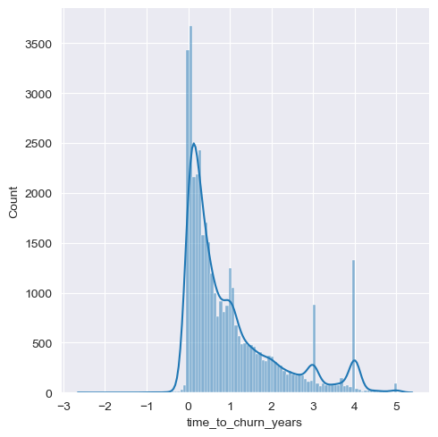

```python
sns.displot(data=df[df["churn"] == 1], x="time_to_churn_years", kde=True)
```

```python
df.groupby(["product"]).agg({"churn":"mean"})
```

| product | churn |
| --- | --- |
| product_a | 0.363749 |
| product_b | 0.295366 |
| product_c | 0.460775 |

different products, different churn! great!

```python
df.groupby(["product", "churn"]).agg({"commission":"mean"})
```

| product | churn | commission |
| --- | --- | --- |
| product_a | 0 | 12.434831 |
|  | 1 | 12.223673 |
| product_b | 0 | 13.788468 |
|  | 1 | 14.546171 |
| product_c | 0 | 18.855637 |
|  | 1 | 19.699258 |

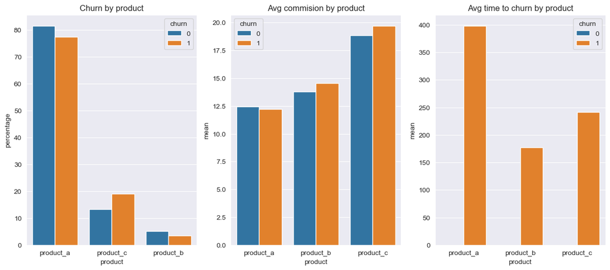

```python
# PRODUCT
fig, axes = plt.subplots(nrows=1, ncols=3, figsize=(15, 6))

## What type of product do churned customers buy?
plt.subplot(1,3,1)
counts = (df.groupby(['churn'])['product']
  .value_counts(normalize=True)
  .rename('percentage')
  .mul(100)
  .reset_index())

counts.columns = ["churn", "product", "percentage"]

plot = sns.barplot(x="product", y="percentage", hue="churn", data=counts).set_title('Churn by product')

## Average commission by product?
plt.subplot(1,3,2)
counts = (df.groupby(["product", "churn"])['commission']
  .mean()
  .rename('mean')
  .reset_index())

counts.columns = [ "product", "churn", "mean"]

plot = sns.barplot(x="product", y="mean", hue="churn", data=counts).set_title('Avg commision by product')

## Average time to churn by product?
plt.subplot(1,3,3)
counts = (df.groupby(["product", "churn"])['time_to_churn']
  .mean()
  .rename('mean')
  .reset_index())

counts.columns = [ "product", "churn", "mean"]

plot = sns.barplot(x="product", y="mean", hue="churn", data=counts).set_title('Avg time to churn by product')
```

```python
df.groupby(["age_bucket", "churn"]).agg({"commission":"sum"})
```

| age_bucket | churn | commission |
| --- | --- | --- |
| 18-24 | 0 | 84228.2825 |
|  | 1 | 52222.6975 |
| 25-29 | 0 | 191702.1625 |
|  | 1 | 101345.6600 |
| 30-34 | 0 | 193732.5575 |
|  | 1 | 112273.5450 |
| 35-39 | 0 | 115449.7450 |
|  | 1 | 82542.5550 |
| 40-44 | 0 | 72716.1175 |
|  | 1 | 58748.2000 |
| 45-49 | 0 | 50647.0275 |
|  | 1 | 38231.8050 |
| 50-54 | 0 | 50004.8525 |
|  | 1 | 29582.5050 |
| 55+ | 0 | 97549.3875 |
|  | 1 | 53832.3050 |
| undefined | 0 | 134.6450 |
|  | 1 | 549.9000 |

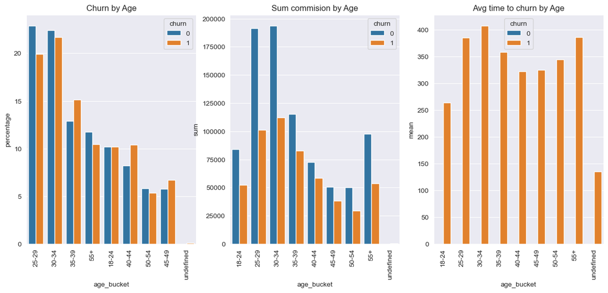

```python
# AGE BUCKET
fig, axes = plt.subplots(nrows=1, ncols=3, figsize=(15, 6))

## What age_bucket do churned customers have?
plt.subplot(1,3,1)
counts = (df.groupby(['churn'])['age_bucket']
  .value_counts(normalize=True)
  .rename('percentage')
  .mul(100)
  .reset_index())

counts.columns = ["churn", "age_bucket", "percentage"]

plot = sns.barplot(x="age_bucket", y="percentage", hue="churn", data=counts).set_title('Churn by Age')
plt.xticks(rotation=90)

## Sum commission by age?
plt.subplot(1,3,2)
counts = (df.groupby(["age_bucket", "churn"])['commission']
  .sum()
  .rename('sum')
  .reset_index())

counts.columns = [ "age_bucket", "churn", "sum"]

plot = sns.barplot(x="age_bucket", y="sum", hue="churn", data=counts).set_title('Sum commision by Age')
plt.xticks(rotation=90)

## Average time to churn by Age?
plt.subplot(1,3,3)
counts = (df.groupby(["age_bucket", "churn"])['time_to_churn']
  .mean()
  .rename('mean')
  .reset_index())

counts.columns = [ "age_bucket", "churn", "mean"]

plot = sns.barplot(x="age_bucket", y="mean", hue="churn", data=counts).set_title('Avg time to churn by Age')
plt.xticks(rotation=90)
plt.show()
```

```python
df.groupby(["channel", "churn"]).agg({"commission":"sum"})
```

| channel | churn | commission |
| --- | --- | --- |
| channel_a | 0 | 359550.2000 |
|  | 1 | 241305.0725 |
| channel_b | 0 | 496614.5775 |
|  | 1 | 288024.1000 |

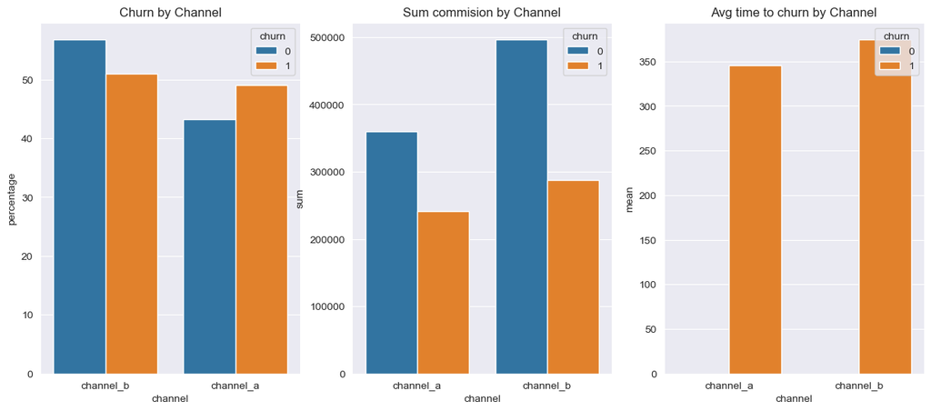

```python
# CHANNEL
fig, axes = plt.subplots(nrows=1, ncols=3, figsize=(15, 6))

## What channel do churned customers use?
plt.subplot(1,3,1)
counts = (df.groupby(['churn'])['channel']
  .value_counts(normalize=True)
  .rename('percentage')
  .mul(100)
  .reset_index())

counts.columns = ["churn", "channel", "percentage"]

plot = sns.barplot(x="channel", y="percentage", hue="churn", data=counts).set_title('Churn by Channel')

## Sum commission by channel?
plt.subplot(1,3,2)
counts = (df.groupby(["channel", "churn"])['commission']
  .sum()
  .rename('sum')
  .reset_index())

counts.columns = [ "channel", "churn", "sum"]

plot = sns.barplot(x="channel", y="sum", hue="churn", data=counts).set_title('Sum commision by Channel')

## Average time to churn by channel?
plt.subplot(1,3,3)
counts = (df.groupby(["channel", "churn"])['time_to_churn']
  .mean()
  .rename('mean')
  .reset_index())

counts.columns = [ "channel", "churn", "mean"]

plot = sns.barplot(x="channel", y="mean", hue="churn", data=counts).set_title('Avg time to churn by Channel')
```

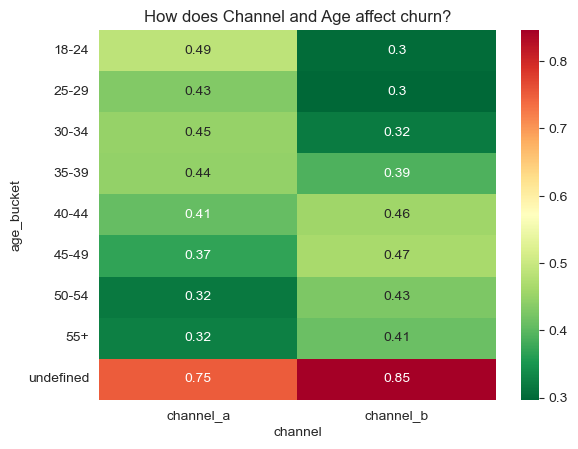

```python
# How does Channel and Age affect churn?
## Create pivot table
result = pd.pivot_table(data=df, index='age_bucket', columns='channel',values='churn')
## create heat map of education vs marital vs response_rate
sns.heatmap(result, annot=True, cmap = 'RdYlGn_r').set_title('How does Channel and Age affect churn?')
plt.show()
```

```python
df.groupby(["operating_system", "churn"]).agg({"commission":"sum"})
```

| operating_system | churn | commission |
| --- | --- | --- |
| Android | 0 | 383821.0375 |
|  | 1 | 271425.7625 |
| iOS | 0 | 433941.1325 |
|  | 1 | 202315.9550 |
| iPadOS | 0 | 8144.7400 |
|  | 1 | 2080.7975 |
| iPhone OS | 0 | 10.0000 |
|  | 1 | 184.5575 |

hmmm shouldnt all summed up? because its iOS br family?

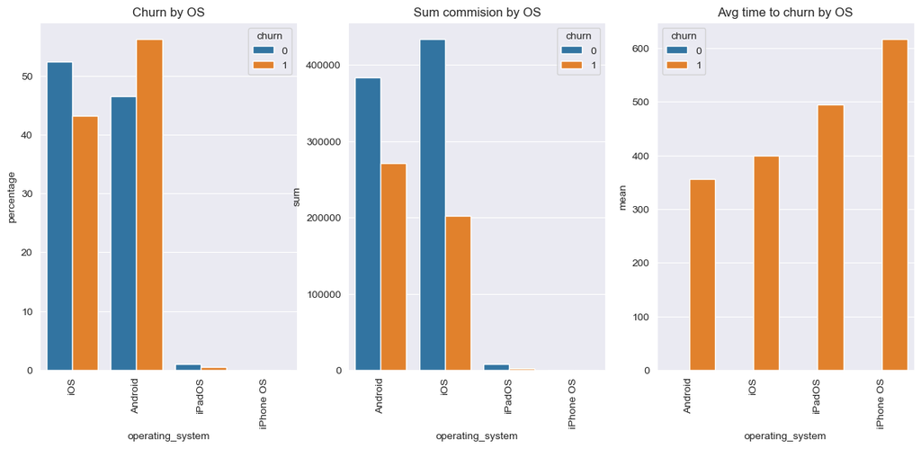

```python
# OPERATING SYSTEM
fig, axes = plt.subplots(nrows=1, ncols=3, figsize=(15, 6))

## What operating system do churned customers have?
plt.subplot(1,3,1)
counts = (df.groupby(['churn'])['operating_system']
  .value_counts(normalize=True)
  .rename('percentage')
  .mul(100)
  .reset_index())

counts.columns = ["churn", "operating_system", "percentage"]

plot = sns.barplot(x="operating_system", y="percentage", hue="churn", data=counts).set_title('Churn by OS')
plt.xticks(rotation=90)

## Sum commission by operating system?
plt.subplot(1,3,2)
counts = (df.groupby(["operating_system", "churn"])['commission']
  .sum()
  .rename('sum')
  .reset_index())

counts.columns = [ "operating_system", "churn", "sum"]

plot = sns.barplot(x="operating_system", y="sum", hue="churn", data=counts).set_title('Sum commision by OS')
plt.xticks(rotation=90)

## Average time to churn by operating system?
plt.subplot(1,3,3)
counts = (df.groupby(["operating_system", "churn"])['time_to_churn']
  .mean()
  .rename('mean')
  .reset_index())

counts.columns = [ "operating_system", "churn", "mean"]

plot = sns.barplot(x="operating_system", y="mean", hue="churn", data=counts).set_title('Avg time to churn by OS')
plt.xticks(rotation=90)
plt.show()
```

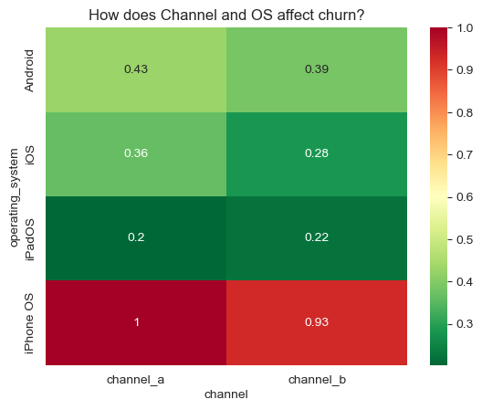

```python
# How does Channel and OS affect churn?
## Create pivot table
result = pd.pivot_table(data=df, index='operating_system', columns='channel',values='churn')
## create heat map of education vs marital vs response_rate
sns.heatmap(result, annot=True, cmap = 'RdYlGn_r').set_title('How does Channel and OS affect churn?')
plt.show()
```

#### Joining cross-sell data

```python
df[df.customer_started_at == df.customer_started_at.min()]
```

|  | user_id | customer_started_at | customer_churned_at | product | commission | channel | age_bucket | operating_system | churn | time_to_churn | time_to_churn_months | time_to_churn_years | 12m_p | active_months |
| --- | --- | --- | --- | --- | --- | --- | --- | --- | --- | --- | --- | --- | --- | --- |
| 29140 | a3aa684357 | 2017-11-24 | NaT | product_a | 12.520 | channel_b | 35-39 | iOS | 0 | NaN | NaN | NaN | 6 | 69 |
| 30388 | cef631a4ac | 2017-11-24 | NaT | product_a | 11.765 | channel_b | 30-34 | iOS | 0 | NaN | NaN | NaN | 6 | 69 |
| 43048 | ca1eaba373 | 2017-11-24 | 2021-10-19 | product_a | 11.765 | channel_b | 30-34 | Android | 1 | 1425.0 | 46.81821 | 3.901517 | 6 | 46 |
| 65306 | a47e7d836b | 2017-11-24 | NaT | product_a | 11.765 | channel_a | 30-34 | iOS | 0 | NaN | NaN | NaN | 6 | 69 |
| 100170 | 6fb22d9169 | 2017-11-24 | NaT | product_a | 11.765 | channel_b | 30-34 | Android | 0 | NaN | NaN | NaN | 6 | 69 |

We also have some `user_id` in our dataset with more than 12 months. The question is how do we split the data into train and testing?

What is the LTV for a client like `ca1eaba373` that join on `2017-11-24` and churned on `2021-10-19`?

How can we split our data into train and test?

## Cross Selling Dataset

```python
cross_sell = pd.read_csv("./data/...csv", parse_dates=['date'])
```

```python
cross_sell.columns
```

```
Index(['user_id', 'product', 'commission', 'date'], dtype='object')
```

```python
cross_sell
```

|  | user_id | product | commission | date |
| --- | --- | --- | --- | --- |
| 0 | ccc05d82e1 | product_y | 499.6000 | 2022-08-05 |
| 1 | 77a488f223 | product_y | 821.2950 | 2022-10-20 |
| 2 | e717cb5a0b | product_y | 1215.0350 | 2023-01-19 |
| 3 | 1e9ca78b5b | product_y | 413.1800 | 2022-12-20 |
| 4 | eee1f85c5c | product_y | 354.4475 | 2022-10-06 |
| ... | ... | ... | ... | ... |
| 1313 | b46d770837 | product_y | 579.6650 | 2022-11-01 |
| 1314 | af3b28aac0 | product_y | 418.3700 | 2022-10-11 |
| 1315 | 623b0fe810 | product_x | 1269.0025 | 2022-06-30 |
| 1316 | 3cc2642221 | product_y | 377.0550 | 2022-09-22 |
| 1317 | c9699ea28e | product_y | 1421.0200 | 2022-09-27 |

1318 rows × 4 columns

```python
cross_sell.info()
```

```
<class 'pandas.core.frame.DataFrame'>
RangeIndex: 1318 entries, 0 to 1317
Data columns (total 4 columns):
 #   Column      Non-Null Count  Dtype
---  ------      --------------  -----
 0   user_id     1318 non-null   object
 1   product     1318 non-null   object
 2   commission  1055 non-null   float64
 3   date        1318 non-null   datetime64[ns]
dtypes: datetime64[ns](1), float64(1), object(2)
memory usage: 41.3+ KB
```

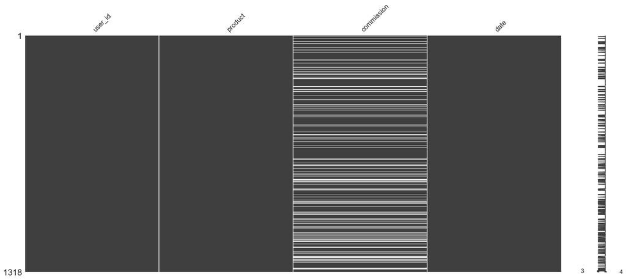

```python
msno.matrix(cross_sell)
```

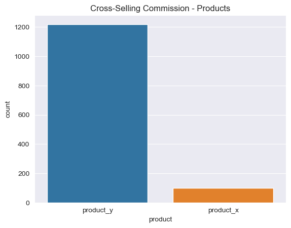

```python
sns.countplot(data=cross_sell, x="product")
plt.title("Cross-Selling Commission - Products")
```

```python
cross_sell.groupby(['product']).agg({"commission":"min"})
```

| product | commission |
| --- | --- |
| product_x | 19.6675 |
| product_y | 10.0000 |

```python
cross_sell.groupby(['product']).agg({"commission":"mean"})
```

| product | commission |
| --- | --- |
| product_x | 987.036930 |
| product_y | 667.207677 |

```python
cross_sell.groupby(['product']).agg({"commission":"median"})
```

| product | commission |
| --- | --- |
| product_x | 1157.025 |
| product_y | 526.850 |

```python
cross_sell.groupby(['product']).agg({"commission":"sum"})
```

| product | commission |
| --- | --- |
| product_x | 77975.9175 |
| product_y | 651194.6925 |

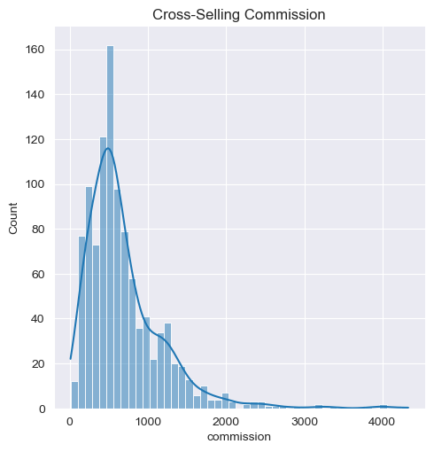

```python
sns.displot(data=cross_sell, x="commission", kde=True)
plt.title("Cross-Selling Commission")
```

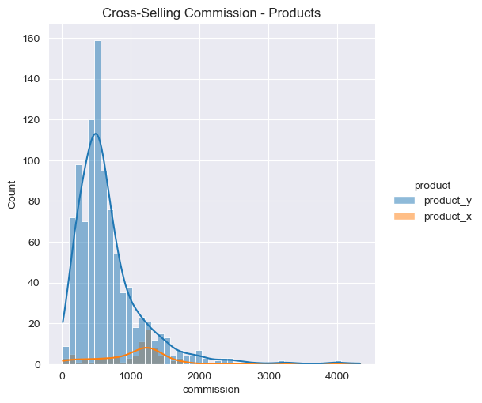

```python
sns.displot(data=cross_sell, x="commission", hue='product', kde=True)
plt.title("Cross-Selling Commission - Products")
```

```python
cross_sell.user_id.nunique()
```

```
1143
```

Are all customers from the cross selling dataset in the original df?

```python
set(cross_sell.user_id.unique()).issubset(set(df.user_id.unique()))
```

```
True
```

```python
df[df.user_id == "ccc05d82e1"]
```

|  | user_id | customer_started_at | customer_churned_at | product | commission | channel | age_bucket | operating_system | churn | time_to_churn | time_to_churn_months | time_to_churn_years | 12m_p | active_months |
| --- | --- | --- | --- | --- | --- | --- | --- | --- | --- | --- | --- | --- | --- | --- |
| 61153 | ccc05d82e1 | 2020-03-16 | NaT | product_c | 24.275 | channel_b | 30-34 | iOS | 0 | NaN | NaN | NaN | 4 | 41 |

```python
cross_sell[cross_sell.user_id == "ccc05d82e1"]
```

|  | user_id | product | commission | date |
| --- | --- | --- | --- | --- |
| 0 | ccc05d82e1 | product_y | 499.6 | 2022-08-05 |

```python
df
```

|  | user_id | customer_started_at | customer_churned_at | product | commission | channel | age_bucket | operating_system | churn | time_to_churn | time_to_churn_months | time_to_churn_years | 12m_p | active_months |
| --- | --- | --- | --- | --- | --- | --- | --- | --- | --- | --- | --- | --- | --- | --- |
| 0 | 37d76d441d | 2020-12-01 | NaT | product_a | 12.1775 | channel_a | 55+ | iOS | 0 | NaN | NaN | NaN | 3 | 32 |
| 1 | cdc1327d79 | 2022-05-09 | NaT | product_a | 12.4575 | channel_a | 18-24 | iOS | 0 | NaN | NaN | NaN | 2 | 15 |
| 2 | fac8c03aa8 | 2021-11-20 | 2023-01-01 | product_c | 21.6625 | channel_a | 35-39 | Android | 1 | 407.0 | 13.371938 | 1.114328 | 2 | 13 |
| 3 | b0c703a998 | 2020-05-21 | NaT | product_a | 12.0475 | channel_b | 35-39 | Android | 0 | NaN | NaN | NaN | 4 | 39 |
| 4 | 0276bcc756 | 2021-04-15 | NaT | product_c | 15.7700 | channel_b | 35-39 | Android | 0 | NaN | NaN | NaN | 3 | 28 |
| ... | ... | ... | ... | ... | ... | ... | ... | ... | ... | ... | ... | ... | ... | ... |
| 102618 | 7df1a34a0d | 2021-02-12 | NaT | product_a | 12.6825 | channel_a | 45-49 | iOS | 0 | NaN | NaN | NaN | 3 | 30 |
| 102619 | 58ce7b5a49 | 2022-11-27 | NaT | product_b | 13.6975 | channel_a | 45-49 | iOS | 0 | NaN | NaN | NaN | 1 | 9 |
| 102620 | 4744036910 | 2022-07-22 | NaT | product_a | 12.1925 | channel_a | 45-49 | iOS | 0 | NaN | NaN | NaN | 2 | 13 |
| 102621 | ca58e4734d | 2021-07-16 | NaT | product_a | 13.7525 | channel_a | 50-54 | Android | 0 | NaN | NaN | NaN | 3 | 25 |
| 102622 | b1677c3ae1 | 2021-09-22 | NaT | product_a | 13.1950 | channel_b | 18-24 | iOS | 0 | NaN | NaN | NaN | 2 | 23 |

102623 rows × 14 columns

# LTV Calculation

Calculate Monthly Commissions for the First 12 Months: Identify the monthly commissions earned from each customer for the first 12 months after they join. This could include premiums or other regular payment streams.

$$\text{Monthly Commissions} = \sum_{i=1}^{12} \text{Commission}_{\text{month}_i}$$

Calculate One-Time Commissions from Cross-Sell Products: Identify any additional products that were purchased by the customer during that 12-month period, and sum the commissions earned from these products.

Cross-Sell Commissions

$$ \text{Cross-Sell Commissions} = \sum \text{Commission}_{\text{cross-sell products}} $$

Sum the Monthly Commissions and Cross-Sell Commissions:

$$ \text{LTV} = \text{Monthly Commissions} + \text{Cross-Sell Commissions} $$

```python
def compute_revenue(x):

    commission = x["commission"].dropna().unique().tolist()[0]

    date_cutoff = x["customer_started_at"].iloc[0] + pd.DateOffset(months=12)

    total_commission_cross = np.sum(x[x["customer_started_at_cross"] <= date_cutoff]["commission_cross"].dropna())

    tenure = x["tenure_months"].dropna().unique().tolist()[0]

    product_seq = x["product"].dropna().unique().tolist()



    if tenure > 12:
        revenue = commission * 12 + total_commission_cross
    if tenure <= 12:
        revenue = commission * tenure + total_commission_cross

    cross_bool = total_commission_cross > 0

    return revenue, cross_bool, product_seq
```

```python
print(f"Because there are no common products, but there are common users, the resulting df has to have {df.shape[0] + cross_sell.shape[0]} rows")
```

```
Because there are no common products, but there are common users, the resulting df has to have 103941 rows
```

```python
print(f"Meaning outer join on `user` and `product`")
```

```
Meaning outer join on `user` and `product`
```

```python
df['customer_started_at'] = pd.to_datetime(df['customer_started_at'])
df['customer_churned_at'] = pd.to_datetime(df['customer_churned_at'])
df['tenure'] = np.where(df['customer_churned_at'].isnull(), datetime.now() - df['customer_started_at'], df['customer_churned_at'] - df['customer_started_at'])
df['tenure'] = df['tenure'].dt.days


df['tenure_months'] = df['tenure'] // 30
df['tenure_years'] = df['tenure'] // 365


# Add temporal features
df['month'] = df['customer_started_at'].dt.month
df['quarter'] = df['customer_started_at'].dt.quarter

# Preprocess cross-sell data
cross_sell['date'] = pd.to_datetime(cross_sell['date'])

cross_sell = cross_sell.groupby(['user_id', 'product', 'date']).agg({"commission":"sum"}).reset_index()

cross_sell = cross_sell.rename(columns={"date":"customer_started_at"})


# Merge the two datasets on user_id and date
df_merged = df.merge(cross_sell, how='outer', left_on=['user_id'], right_on=['user_id'], suffixes=['', '_cross'])
df_mergedp = df.merge(cross_sell, how='outer', left_on=['user_id', 'product'], right_on=['user_id', 'product'], suffixes=['', '_cross'])

df_mergedp['churn'] = df_mergedp.groupby(['user_id', 'product'])['churn'].bfill().ffill()
```

```python
df_mergedp.head()
```

|  | user_id | customer_started_at | customer_churned_at | product | commission | channel | age_bucket | operating_system | churn | time_to_churn | ... | time_to_churn_years | 12m_p | active_months | tenure | tenure_months | tenure_years | month | quarter | customer_started_at_cross | commission_cross |
| --- | --- | --- | --- | --- | --- | --- | --- | --- | --- | --- | --- | --- | --- | --- | --- | --- | --- | --- | --- | --- | --- |
| 0 | 37d76d441d | 2020-12-01 | NaT | product_a | 12.1775 | channel_a | 55+ | iOS | 0.0 | NaN | ... | NaN | 3.0 | 32.0 | 1000.0 | 33.0 | 2.0 | 12.0 | 4.0 | NaT | NaN |
| 1 | cdc1327d79 | 2022-05-09 | NaT | product_a | 12.4575 | channel_a | 18-24 | iOS | 0.0 | NaN | ... | NaN | 2.0 | 15.0 | 476.0 | 15.0 | 1.0 | 5.0 | 2.0 | NaT | NaN |
| 2 | fac8c03aa8 | 2021-11-20 | 2023-01-01 | product_c | 21.6625 | channel_a | 35-39 | Android | 1.0 | 407.0 | ... | 1.114328 | 2.0 | 13.0 | 407.0 | 13.0 | 1.0 | 11.0 | 4.0 | NaT | NaN |
| 3 | b0c703a998 | 2020-05-21 | NaT | product_a | 12.0475 | channel_b | 35-39 | Android | 0.0 | NaN | ... | NaN | 4.0 | 39.0 | 1194.0 | 39.0 | 3.0 | 5.0 | 2.0 | NaT | NaN |
| 4 | 0276bcc756 | 2021-04-15 | NaT | product_c | 15.7700 | channel_b | 35-39 | Android | 0.0 | NaN | ... | NaN | 3.0 | 28.0 | 865.0 | 28.0 | 2.0 | 4.0 | 2.0 | NaT | NaN |

5 rows × 21 columns

```python
user_revenue = df_mergedp.groupby(["user_id"]).apply(lambda x: compute_revenue(x.sort_values(by=["customer_started_at"])))

user_revenue
```

```
user_id
0001a5331c    (199.17000000000002, False, [product_c])
00028d8670                   (0.0, False, [product_a])
000305a02c               (12.5575, False, [product_a])
0003ee127e                (150.69, False, [product_a])
00055d1b95                (158.34, False, [product_a])
                                ...
fffcd749b2                (165.57, False, [product_a])
ffff070877               (72.3625, False, [product_a])
ffff597410                 (87.57, False, [product_a])
ffff75077c                (110.64, False, [product_c])
ffff89cb0b                 (25.74, False, [product_c])
Length: 102623, dtype: object
```

```python
user_rev = pd.DataFrame.from_records(user_revenue, columns=['ltv',
                                                            'cross_sell',
                                                            'product_seq'], index=user_revenue.index)
user_rev
```

| user_id | ltv | cross_sell | product_seq |
| --- | --- | --- | --- |
| 0001a5331c | 199.1700 | False | [product_c] |
| 00028d8670 | 0.0000 | False | [product_a] |
| 000305a02c | 12.5575 | False | [product_a] |
| 0003ee127e | 150.6900 | False | [product_a] |
| 00055d1b95 | 158.3400 | False | [product_a] |
| ... | ... | ... | ... |
| fffcd749b2 | 165.5700 | False | [product_a] |
| ffff070877 | 72.3625 | False | [product_a] |
| ffff597410 | 87.5700 | False | [product_a] |
| ffff75077c | 110.6400 | False | [product_c] |
| ffff89cb0b | 25.7400 | False | [product_c] |

102623 rows × 3 columns

```python
user_rev["product_seq"].value_counts(normalize=True)
```

```
[product_a]                          0.791441
[product_c]                          0.152675
[product_b]                          0.044746
[product_a, product_y]               0.007688
[product_c, product_y]               0.002280
[product_a, product_x]               0.000575
[product_b, product_y]               0.000234
[product_a, product_x, product_y]    0.000156
[product_c, product_x]               0.000146
[product_c, product_x, product_y]    0.000039
[product_b, product_x]               0.000019
Name: product_seq, dtype: float64
```

```python
user_rev["product_seq"] = user_rev["product_seq"].astype(str)
```

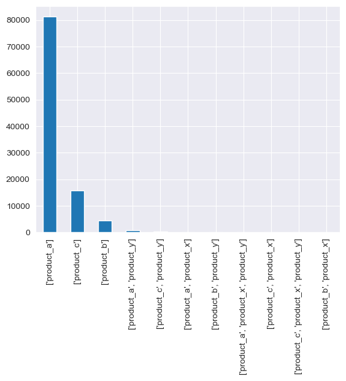

```python
user_rev["product_seq"].value_counts().plot(kind="bar")
```

```python
df = df.set_index("user_id")
```

```python
dfmodel = df.join(user_rev)
```

```python
dfmodel.head()
```

| user_id | customer_started_at | customer_churned_at | product | commission | channel | age_bucket | operating_system | churn | time_to_churn | time_to_churn_months | ... | 12m_p | active_months | tenure | tenure_months | tenure_years | month | quarter | ltv | cross_sell | product_seq |
| --- | --- | --- | --- | --- | --- | --- | --- | --- | --- | --- | --- | --- | --- | --- | --- | --- | --- | --- | --- | --- | --- |
| 37d76d441d | 2020-12-01 | NaT | product_a | 12.1775 | channel_a | 55+ | iOS | 0 | NaN | NaN | ... | 3 | 32 | 1000 | 33 | 2 | 12 | 4 | 146.13 | False | ['product_a'] |
| cdc1327d79 | 2022-05-09 | NaT | product_a | 12.4575 | channel_a | 18-24 | iOS | 0 | NaN | NaN | ... | 2 | 15 | 476 | 15 | 1 | 5 | 2 | 149.49 | False | ['product_a'] |
| fac8c03aa8 | 2021-11-20 | 2023-01-01 | product_c | 21.6625 | channel_a | 35-39 | Android | 1 | 407.0 | 13.371938 | ... | 2 | 13 | 407 | 13 | 1 | 11 | 4 | 259.95 | False | ['product_c'] |
| b0c703a998 | 2020-05-21 | NaT | product_a | 12.0475 | channel_b | 35-39 | Android | 0 | NaN | NaN | ... | 4 | 39 | 1194 | 39 | 3 | 5 | 2 | 144.57 | False | ['product_a'] |
| 0276bcc756 | 2021-04-15 | NaT | product_c | 15.7700 | channel_b | 35-39 | Android | 0 | NaN | NaN | ... | 3 | 28 | 865 | 28 | 2 | 4 | 2 | 189.24 | False | ['product_c'] |

5 rows × 21 columns

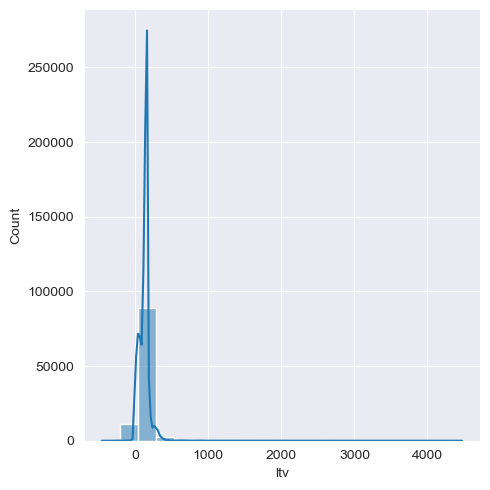

```python
sns.displot(data=dfmodel, x='ltv', kde=True, bins=20)
```

```python
dfmodel["cross_sell"].value_counts()
```

```
False    102185
True        438
Name: cross_sell, dtype: int64
```

```python
cross_sell[cross_sell.commission>0].user_id.nunique()
```

```
920
```

### Model Building/Validation/Tuning

```python
cat_cols = []
target_cols = []
num_cols = []
for c in dfmodel.columns:
    col_type = dfmodel[c].dtype
    if c != "ltv":
        if col_type == "object" or col_type.name == "category":
            dfmodel[c] = dfmodel[c].astype('category')
            cat_cols.append(c)
        elif col_type == "float64" or col_type == "int64":
            num_cols.append(c)
    else:
        target_cols.append(c)
```

```python
train_df = dfmodel[dfmodel["12m_p"].isin(dfmodel["12m_p"].value_counts().sort_index().index[:-1]).tolist()]
test_df = dfmodel[dfmodel["12m_p"].isin(dfmodel["12m_p"].value_counts().sort_index().index[-1:]).tolist()]
```

```python
train_df.head()
```

| user_id | customer_started_at | customer_churned_at | product | commission | channel | age_bucket | operating_system | churn | time_to_churn | time_to_churn_months | ... | 12m_p | active_months | tenure | tenure_months | tenure_years | month | quarter | ltv | cross_sell | product_seq |
| --- | --- | --- | --- | --- | --- | --- | --- | --- | --- | --- | --- | --- | --- | --- | --- | --- | --- | --- | --- | --- | --- |
| 37d76d441d | 2020-12-01 | NaT | product_a | 12.1775 | channel_a | 55+ | iOS | 0 | NaN | NaN | ... | 3 | 32 | 1000 | 33 | 2 | 12 | 4 | 146.13 | False | ['product_a'] |
| cdc1327d79 | 2022-05-09 | NaT | product_a | 12.4575 | channel_a | 18-24 | iOS | 0 | NaN | NaN | ... | 2 | 15 | 476 | 15 | 1 | 5 | 2 | 149.49 | False | ['product_a'] |
| fac8c03aa8 | 2021-11-20 | 2023-01-01 | product_c | 21.6625 | channel_a | 35-39 | Android | 1 | 407.0 | 13.371938 | ... | 2 | 13 | 407 | 13 | 1 | 11 | 4 | 259.95 | False | ['product_c'] |
| b0c703a998 | 2020-05-21 | NaT | product_a | 12.0475 | channel_b | 35-39 | Android | 0 | NaN | NaN | ... | 4 | 39 | 1194 | 39 | 3 | 5 | 2 | 144.57 | False | ['product_a'] |
| 0276bcc756 | 2021-04-15 | NaT | product_c | 15.7700 | channel_b | 35-39 | Android | 0 | NaN | NaN | ... | 3 | 28 | 865 | 28 | 2 | 4 | 2 | 189.24 | False | ['product_c'] |

5 rows × 21 columns

```python
train_df.info()
```

```
<class 'pandas.core.frame.DataFrame'>
Index: 99695 entries, 37d76d441d to b1677c3ae1
Data columns (total 21 columns):
 #   Column                Non-Null Count  Dtype
---  ------                --------------  -----
 0   customer_started_at   99695 non-null  datetime64[ns]
 1   customer_churned_at   36794 non-null  datetime64[ns]
 2   product               99695 non-null  category
 3   commission            99695 non-null  float64
 4   channel               99695 non-null  category
 5   age_bucket            99695 non-null  category
 6   operating_system      93997 non-null  category
 7   churn                 99695 non-null  int64
 8   time_to_churn         36794 non-null  float64
 9   time_to_churn_months  36794 non-null  float64
 10  time_to_churn_years   36794 non-null  float64
 11  12m_p                 99695 non-null  int64
 12  active_months         99695 non-null  int64
 13  tenure                99695 non-null  int64
 14  tenure_months         99695 non-null  int64
 15  tenure_years          99695 non-null  int64
 16  month                 99695 non-null  int64
 17  quarter               99695 non-null  int64
 18  ltv                   99695 non-null  float64
 19  cross_sell            99695 non-null  bool
 20  product_seq           99695 non-null  category
dtypes: bool(1), category(5), datetime64[ns](2), float64(5), int64(8)
memory usage: 12.7+ MB
```

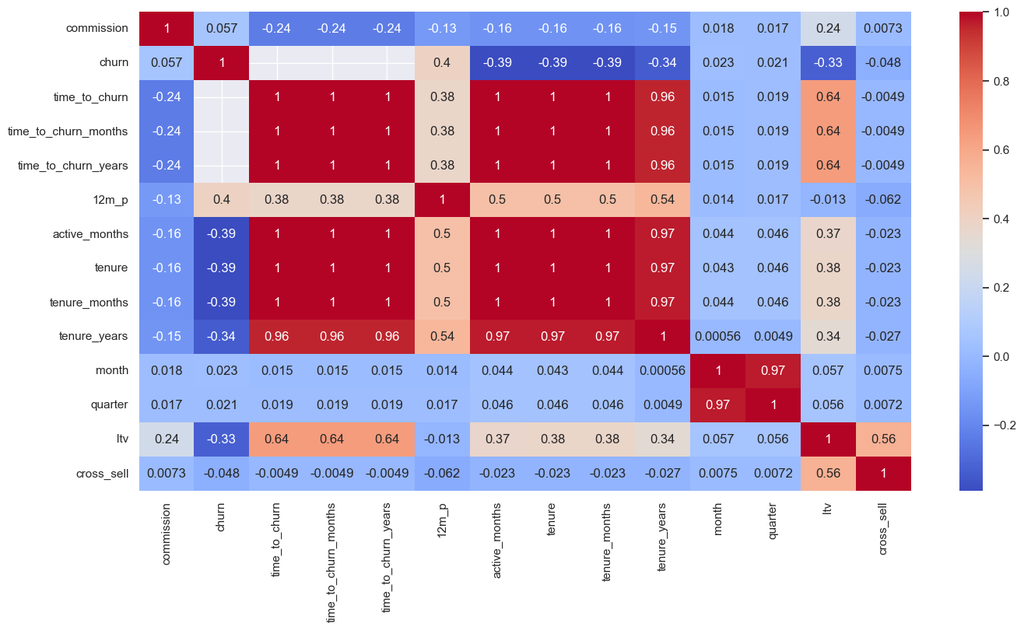

```python
sns.set(rc = {'figure.figsize':(16,8)})
sns.heatmap(train_df.corr(), annot = True, fmt='.2g',cmap= 'coolwarm')
```

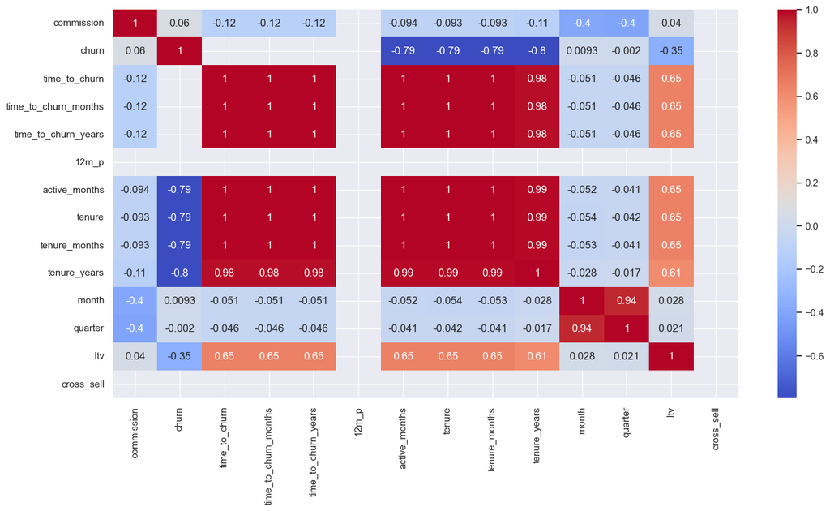

```python
sns.set(rc = {'figure.figsize':(16,8)})
sns.heatmap(test_df.corr(), annot = True, fmt='.2g',cmap= 'coolwarm')
```

```python
cat_cols
```

```
['product', 'channel', 'age_bucket', 'operating_system', 'product_seq']
```

```python
num_cols
```

```
['commission',
 'churn',
 'time_to_churn',
 'time_to_churn_months',
 'time_to_churn_years',
 '12m_p',
 'active_months',
 'tenure',
 'tenure_months',
 'tenure_years',
 'month',
 'quarter']
```

```python
target_cols
```

```
['ltv']
```